# STATGR5243_LANGER_ASN1

Data Science Notebook - Philosophy Data Project, Peter Langer (pjl2144)

Importing Libraries

```python
import numpy as np
import pandas as pd
from sklearn.feature_extraction.text import CountVectorizer
from sklearn.feature_extraction.text import TfidfTransformer
from sklearn.decomposition import LatentDirichletAllocation as LDA
from nltk.corpus import stopwords
import re
from matplotlib import pyplot as plt
import warnings
warnings.filterwarnings("ignore", category=DeprecationWarning)
```

Importing Functions from /lib

```python
import helper_functions
```

Importing Data

```python
#Change this path to relative
#os.chdir('..') #cd to the download folder

df = pd.read_csv('/Users/peter/Downloads/philosophy_data.csv')
```

```python
#Creating Corpus from Helper Functions (create_corpus is in helper_functions.py)
df_processed, corpusc = create_corpus(df)
```

In the cell above, we did a lot of pre-processing: we stemmed, removed stop words, and created the data structures that we will rely on for the remainder of the analysis. The return values, df_processed is the pre-processed raw data frame (pandas), and corpusc is the corpus list-of-lists, we will use for Topic Modeling in a later cell. Before we get into more advanced techniques, let's first look at the data a little more:

```
Figure 1.1: A Table of Works Included in the Philosophy Data Project, by number of sentences (Count) and total discrete publications
```

|  | title | author | count | count_total_works |
| --- | --- | --- | --- | --- |
| 0 | A General Theory Of Employment, Interest, And ... | Keynes | 3411 | 1 |
| 1 | A Treatise Concerning The Principles Of Human ... | Berkeley | 1040 | 2 |
| 2 | A Treatise Of Human Nature | Hume | 7047 | 2 |
| 3 | Anti-Oedipus | Deleuze | 6679 | 2 |
| 4 | Aristotle - Complete Works | Aristotle | 48779 | 1 |
| 5 | Being And Time | Heidegger | 8505 | 2 |
| 6 | Beyond Good And Evil | Nietzsche | 1906 | 5 |
| 7 | Capital | Marx | 12996 | 2 |
| 8 | Critique Of Judgement | Kant | 4204 | 3 |
| 9 | Critique Of Practical Reason | Kant | 2452 | 3 |
| 10 | Critique Of Pure Reason | Kant | 7472 | 3 |
| 11 | Dialogues Concerning Natural Religion | Hume | 1265 | 2 |
| 12 | Difference And Repetition | Deleuze | 5861 | 2 |
| 13 | Discourse On Method | Descartes | 340 | 2 |
| 14 | Ecce Homo | Nietzsche | 1504 | 5 |
| 15 | Elements Of The Philosophy Of Right | Hegel | 4923 | 3 |
| 16 | Enchiridion | Epictetus | 323 | 1 |
| 17 | Essay Concerning Human Understanding | Locke | 7742 | 2 |
| 18 | Essential Works Of Lenin | Lenin | 4469 | 1 |
| 19 | Ethics | Spinoza | 3304 | 2 |

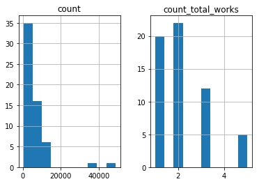

```python
print("Figure 1.1: A Table of Works Included in the Philosophy Data Project, by number of sentences (Count) and total discrete publications")
aggregation_1_1 = aggregate_metrics(df)
aggregation_1_1.hist()
aggregation_1_1.head(20)
```

Sentiment Scoring Results - by Philosopher

After preprocessing the data, I ran a sentiment intensity algorithm from the nlptk on every sentence from a combined Philosopher-level corpora. I used the VADER method. Composite Scores break down the following way: positive sentiment : (compound score >= 0.05) neutral sentiment : (compound score > -0.05) and (compound score < 0.05) negative sentiment : (compound score <= -0.05) This was to gauge whether or not there were any high-level trends in the authors' corpora. The only author with a 'Negative' average composite score was Angela Davis

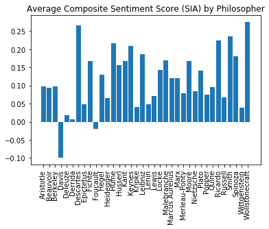

```python
agg_tab_title, agg_tab_auth = generate_graphs(df_processed)
```

```python
agg_tab_auth
print("Figure 1.2 - Chart of Mean Composite Sentiment by Bucket")
print(agg_tab_auth.pivot_table(index = 'sentiment_rate', values = 'composite_sentiment', aggfunc = np.mean))
print("                    ")
print("Figure 1.3 - Composition of Authors in Sample")
print(agg_tab_auth['sentiment_rate'].value_counts()/36)
```

```
Figure 1.2 - Chart of Mean Composite Sentiment by Bucket
                composite_sentiment
sentiment_rate
negative                  -0.099027
neutral                    0.025876
positive                   0.146362

Figure 1.3 - Composition of Authors in Sample
positive    0.777778
neutral     0.194444
negative    0.027778
Name: sentiment_rate, dtype: float64
```

As we see above, a vast majority of the authors returned a POSITIVE VADER score for sentiment. However, there's a great deal of variance below the surface, when examined on a sentence to sentence level. As such, we will examine below some more rigorous mathematical approaches to understanding the sentiment in these corpora.

Sentiment Scores as Stochastic Processes

In a previous step, we generated sentiment scores by sentence using the VADER model. Now, in order to better understand our philosophers, we will apply some autoregressive techniques to see if there are patterns in the works of our dear individual philosophers. First, the method below will run ACFs and PACFs (autocorrelation functions) on the vectors of positional sentiment scores. As the prompt below dictates, these will be saved to the /figs folder for examination Second, because many of the philosophers have significant positional autocorrelation (per the blue confidence band in the charts), we will look at the phi coefficients returned by the procedure and compare the coefficients at various lags as a proxy for evaluating the philosopher's writing or thinking style. We run a k-means cluster on the 10-lags of ACVFs to see how k-means clusters correspond with future clustering we will do using LDA

```python
acf_dictionary = time_series_analysis(df_processed)
```

```
ACF/PACF - Saved to /Users/peter/Downloads/figs/
```

```python
print("An Output of Partial Autocorrelations according to Text Sentiment & K-Means Classes")
dict_acf
```

```
An Output of Partial Autocorrelations according to Text Sentiment & K-Means Classes
```

[output not shown]

```python
from sklearn.cluster import KMeans

dict_acf = pd.DataFrame(acf_dictionary).transpose().reset_index()
km_ready = dict_acf.iloc[:,2:12]
kmeans = KMeans(7) # We choose 7 for a reason
kmeans.fit(km_ready)

dict_acf['kmeans_class'] = kmeans.fit_predict(km_ready)

print('Figure 1.4: K means of autoregressive lag correlations of numerical sentiment scores by Work, not author')
print(dict_acf.groupby(['index','kmeans_class']).size())

dict_acf = dict_acf.rename(columns={"index":"title"})

#dict_acf = pd.merge(dict_acf,df_processed[['title','school']], how='left',on='title')
#Here is some commented out code if you'd like to see what the autocorrelations look like through lags 0-10.

#for j in range(2,12):
#    plt.scatter(y = acf_dictionary_1.iloc[:,j], x = acf_dictionary_1['index'], label = 'Parameter Lag ' + str(j))
#    plt.xticks(rotation=90)
#    plt.show()
#acf_dictionary_1 = pd.melt(acf_dictionary_1, id_vars='index', value_vars=acf_dictionary_1.columns[:-1])
#acf_dictionary_1.head()
#plt.plot(acf_dictionary_1 )
#plt.xticks(rotation=90)
#plt.show()
```

```
Figure 1.4: K means of autoregressive lag correlations of numerical sentiment scores by Work, not author
index                                                    kmeans_class
A General Theory Of Employment, Interest, And Money      6               1
A Treatise Concerning The Principles Of Human Knowledge  0               1
A Treatise Of Human Nature                               1               1
Anti-Oedipus                                             0               1
Aristotle - Complete Works                               1               1
Being And Time                                           1               1
Beyond Good And Evil                                     4               1
Capital                                                  6               1
Critique Of Judgement                                    6               1
Critique Of Practical Reason                             2               1
Critique Of Pure Reason                                  0               1
Dialogues Concerning Natural Religion                    0               1
Difference And Repetition                                2               1
Discourse On Method                                      4               1
Ecce Homo                                                4               1
Elements Of The Philosophy Of Right                      6               1
Enchiridion                                              4               1
Essay Concerning Human Understanding                     0               1
Essential Works Of Lenin                                 0               1
Ethics                                                   6               1
History Of Madness                                       2               1
Lewis - Papers                                           6               1
Meditations                                              2               1
Meditations On First Philosophy                          6               1
Naming And Necessity                                     0               1
Off The Beaten Track                                     6               1
On Certainty                                             0               1
On The Improvement Of Understanding                      3               1
On The Principles Of Political Economy And Taxation      2               1
Philosophical Investigations                             0               1
Philosophical Studies                                    1               1
Philosophical Troubles                                   0               1
Plato - Complete Works                                   6               1
Quintessence                                             4               1
Science Of Logic                                         0               1
Second Treatise On Government                            1               1
The Analysis Of Mind                                     4               1
The Antichrist                                           4               1
The Birth Of The Clinic                                  6               1
The Communist Manifesto                                  5               1
The Crisis Of The European Sciences And Phenomenology    0               1
The Idea Of Phenomenology                                0               1
The Logic Of Scientific Discovery                        0               1
The Order Of Things                                      2               1
The Phenomenology Of Perception                          0               1
The Phenomenology Of Spirit                              0               1
The Problems Of Philosophy                               2               1
The Search After Truth                                   6               1
The Second Sex                                           6               1
The System Of Ethics                                     2               1
The Wealth Of Nations                                    2               1
Theodicy                                                 2               1
Three Dialogues                                          4               1
Thus Spake Zarathustra                                   2               1
Tractatus Logico-Philosophicus                           0               1
Twilight Of The Idols                                    0               1
Vindication Of The Rights Of Woman                       2               1
Women, Race, And Class                                   1               1
Writing And Difference                                   2               1
dtype: int64
```

Topic Modeling

```python
counts = dictionary_parser(corpusc)
```

```
CPU times: user 2 µs, sys: 1 µs, total: 3 µs
Wall time: 5.01 µs
0: 0.012*"one" + 0.009*"thing" + 0.007*"would" + 0.007*"man" + 0.007*"say" + 0.005*"must" + 0.005*"good" + 0.005*"like" + 0.005*"women" + 0.005*"make"

1: 0.008*"one" + 0.008*"would" + 0.007*"upon" + 0.006*"price" + 0.006*"labour" + 0.006*"countri" + 0.006*"great" + 0.005*"valu" + 0.005*"part" + 0.005*"employ"

2: 0.012*"idea" + 0.010*"one" + 0.006*"labour" + 0.006*"may" + 0.005*"natur" + 0.005*"mind" + 0.005*"thing" + 0.005*"us" + 0.004*"object" + 0.004*"exist"

3: 0.011*"one" + 0.008*"say" + 0.007*"may" + 0.007*"mean" + 0.006*"would" + 0.005*"true" + 0.005*"statement" + 0.005*"word" + 0.005*"thing" + 0.005*"use"

4: 0.012*"one" + 0.011*"thing" + 0.008*"god" + 0.007*"would" + 0.006*"natur" + 0.006*"bodi" + 0.006*"us" + 0.006*"must" + 0.006*"say" + 0.005*"reason"

5: 0.016*"one" + 0.010*"thing" + 0.007*"must" + 0.006*"also" + 0.006*"part" + 0.005*"man" + 0.005*"natur" + 0.005*"anim" + 0.005*"case" + 0.005*"say"

6: 0.011*"one" + 0.006*"would" + 0.006*"world" + 0.005*"object" + 0.005*"form" + 0.005*"mean" + 0.004*"languag" + 0.004*"possibl" + 0.004*"mad" + 0.004*"natur"

7: 0.011*"one" + 0.009*"determin" + 0.009*"object" + 0.007*"concept" + 0.007*"natur" + 0.006*"thing" + 0.006*"world" + 0.005*"exist" + 0.005*"self" + 0.005*"also"

 Doc Level
```

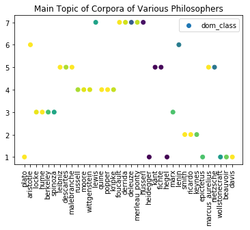

```python
#Internal Code to Generate Charts and Graphs
list_phil=list(corpusc.keys())
dict_philosophers = pd.DataFrame(list_phil).rename(columns={0:'philosopher'})
dict_philosophers['One'] = 0.0
dict_philosophers['Two'] = 0.0
dict_philosophers['Three'] = 0.0
dict_philosophers['Four'] = 0.0
dict_philosophers['Five'] = 0.0
dict_philosophers['Six'] = 0.0
dict_philosophers['Seven'] = 0.0

for c in range(0,len(counts)):
    for p in counts[c]:
        if p[0] == 0:
            dict_philosophers.iloc[c,1] = p[1]
        elif p[0] == 1:
            dict_philosophers.iloc[c,2] = p[1]
        elif p[0] == 2:
            dict_philosophers.iloc[c,3] = p[1]
        elif p[0] == 3:
            dict_philosophers.iloc[c,4] = p[1]
        elif p[0] == 4:
            dict_philosophers.iloc[c,5] = p[1]
        elif p[0] == 5:
            dict_philosophers.iloc[c,6] = p[1]
        elif p[0] == 6:
            dict_philosophers.iloc[c,7] = p[1]


dict_philosophers['dom_class'] = dict_philosophers[['One','Two','Three','Four','Five','Six','Seven']].values.argmax(1)+1
dict_philosophers['dom_intensity'] = dict_philosophers[['One','Two','Three','Four','Five','Six','Seven']].values.max(1)
agg_table_author_school = df_processed.pivot_table(index = ['author_strp','school'],values = 'composite_sentiment', aggfunc = np.mean).reset_index()
agg_table_author_school = agg_table_author_school.rename(columns={'author_strp':'philosopher'})
#plt.imshow(dict_philosophers.iloc[:,1:8])
#plt.colorbar()

plt.scatter(x= dict_philosophers['philosopher'], y = dict_philosophers['dom_class'], c = dict_philosophers['dom_intensity'])
dict_philosophers = pd.merge(dict_philosophers,agg_table_author_school, how = 'left',on = 'philosopher')
plt.xticks(rotation=90)
plt.legend()
plt.title('Main Topic of Corpora of Various Philosophers')
plt.show()
#dict_philosophers
agged_implicit_classifications = dict_philosophers.pivot_table(index = ['dom_class','school'],values = 'dom_intensity').reset_index()
```

```python
agged_implicit_classifications
```

|  | dom_class | school | dom_intensity |
| --- | --- | --- | --- |
| 0 | 1 | feminism | 0.772768 |
| 1 | 1 | german_idealism | 0.000000 |
| 2 | 1 | phenomenology | 0.000000 |
| 3 | 1 | plato | 0.997433 |
| 4 | 1 | stoicism | 0.718238 |
| 5 | 2 | capitalism | 0.920688 |
| 6 | 3 | communism | 0.715332 |
| 7 | 3 | empiricism | 0.887355 |
| 8 | 3 | rationalism | 0.592828 |
| 9 | 4 | analytic | 0.946229 |
| 10 | 5 | german_idealism | 0.014611 |
| 11 | 5 | nietzsche | 0.392987 |
| 12 | 5 | rationalism | 0.957988 |
| 13 | 5 | stoicism | 0.998321 |
| 14 | 6 | aristotle | 0.999495 |
| 15 | 6 | communism | 0.414265 |
| 16 | 7 | analytic | 0.575446 |
| 17 | 7 | continental | 0.738443 |
| 18 | 7 | phenomenology | 0.476171 |

Tying it all together - "Was Aristotle really a communist?"

We observe some interesting results in the table above, including an apparent relationship between the topics discussed by communist philosophers and classical greek thinker Aristotle. Lets explore this more below.

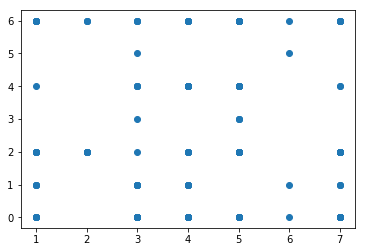

| kmeans_class dom_class | 0 | 1 | 2 | 3 | 4 | 5 | 6 |
| --- | --- | --- | --- | --- | --- | --- | --- |
| 1 | 6.0 | 4.0 | 6.0 | NaN | 1.0 | NaN | 7.0 |
| 2 | NaN | NaN | 6.0 | NaN | NaN | NaN | 3.0 |
| 3 | 10.0 | 6.0 | 1.0 | 1.0 | 4.0 | 1.0 | 4.0 |
| 4 | 36.0 | 6.0 | 6.0 | NaN | 12.0 | NaN | 6.0 |
| 5 | 7.0 | NaN | 9.0 | 3.0 | 7.0 | NaN | 13.0 |
| 6 | 1.0 | 1.0 | NaN | NaN | NaN | 1.0 | 1.0 |
| 7 | 15.0 | 3.0 | 13.0 | NaN | 2.0 | NaN | 6.0 |

```python
df_processed_pro = df_processed.groupby(['author_strp','title','school']).size().reset_index()
df_processed_pro = pd.merge(dict_acf,df_processed_pro, how = 'left', on = 'title')
df_processed_pro = pd.merge(df_processed_pro,dict_philosophers, on = 'school')
plt.scatter(df_processed_pro['dom_class'],df_processed_pro['kmeans_class'], label = 'comparing classification outputs by frequency')
plt.show()
df_processed_pro_fin = df_processed_pro.pivot_table(index = ['dom_class'], columns = 'kmeans_class',values = 'school',aggfunc = 'count')
df_processed_pro_fin
```

```python
df_processed_pro.pivot_table(index = ['author_strp','school','kmeans_class'],values = 'philosopher', aggfunc = 'count').reset_index()
```

|  | author_strp | school | kmeans_class | philosopher |
| --- | --- | --- | --- | --- |
| 0 | aristotle | aristotle | 1 | 1 |
| 1 | beauvoir | feminism | 6 | 3 |
| 2 | berkeley | empiricism | 0 | 3 |
| 3 | berkeley | empiricism | 4 | 3 |
| 4 | davis | feminism | 1 | 3 |
| 5 | deleuze | continental | 0 | 3 |
| 6 | deleuze | continental | 2 | 3 |
| 7 | derrida | continental | 2 | 3 |
| 8 | descartes | rationalism | 4 | 4 |
| 9 | descartes | rationalism | 6 | 4 |
| 10 | epictetus | stoicism | 4 | 2 |
| 11 | fichte | german_idealism | 2 | 3 |
| 12 | foucault | continental | 2 | 6 |
| 13 | foucault | continental | 6 | 3 |
| 14 | hegel | german_idealism | 0 | 6 |
| 15 | hegel | german_idealism | 6 | 3 |
| 16 | heidegger | phenomenology | 1 | 3 |
| 17 | heidegger | phenomenology | 6 | 3 |
| 18 | hume | empiricism | 0 | 3 |
| 19 | hume | empiricism | 1 | 3 |
| 20 | husserl | phenomenology | 0 | 6 |
| 21 | kant | german_idealism | 0 | 3 |
| 22 | kant | german_idealism | 2 | 3 |
| 23 | kant | german_idealism | 6 | 3 |
| 24 | keynes | capitalism | 6 | 3 |
| 25 | kripke | analytic | 0 | 14 |
| 26 | leibniz | rationalism | 2 | 4 |
| 27 | lenin | communism | 0 | 2 |
| 28 | lewis | analytic | 6 | 7 |
| 29 | locke | empiricism | 0 | 3 |
| 30 | locke | empiricism | 1 | 3 |
| 31 | malebranche | rationalism | 6 | 4 |
| 32 | marcus_aurelius | stoicism | 2 | 2 |
| 33 | marx | communism | 5 | 2 |
| 34 | marx | communism | 6 | 2 |
| 35 | merleau_ponty | phenomenology | 0 | 3 |
| 36 | moore | analytic | 1 | 7 |
| 37 | nietzsche | nietzsche | 0 | 1 |
| 38 | nietzsche | nietzsche | 2 | 1 |
| 39 | nietzsche | nietzsche | 4 | 3 |
| 40 | plato | plato | 6 | 1 |
| 41 | popper | analytic | 0 | 7 |
| 42 | quine | analytic | 4 | 7 |
| 43 | ricardo | capitalism | 2 | 3 |
| 44 | russell | analytic | 2 | 7 |
| 45 | russell | analytic | 4 | 7 |
| 46 | smith | capitalism | 2 | 3 |
| 47 | spinoza | rationalism | 3 | 4 |
| 48 | spinoza | rationalism | 6 | 4 |
| 49 | wittgenstein | analytic | 0 | 21 |
| 50 | wollstonecraft | feminism | 2 | 3 |

The above table shows the correspondence between k-means class (derived from sentiment score autoregression) and the label school for a philosopher. This was an imperfect measure because there was actually much more variance in the sentiment clusters than there was in the LDA clusters with respect to philosophical school. As such, maybe the below chart will tell a more compelling story. We can perhaps support some of our conclusions below.

```python
df_processed_pro.pivot_table(index = ['school','dom_class'],values = 'composite_sentiment', aggfunc = 'mean').reset_index()
```

|  | school | dom_class | composite_sentiment |
| --- | --- | --- | --- |
| 0 | analytic | 4 | 0.080721 |
| 1 | analytic | 7 | 0.071562 |
| 2 | aristotle | 6 | 0.097532 |
| 3 | capitalism | 2 | 0.222881 |
| 4 | communism | 3 | 0.120825 |
| 5 | communism | 6 | 0.048409 |
| 6 | continental | 7 | 0.001466 |
| 7 | empiricism | 3 | 0.151546 |
| 8 | feminism | 1 | 0.089688 |
| 9 | german_idealism | 1 | 0.130074 |
| 10 | german_idealism | 5 | 0.167307 |
| 11 | nietzsche | 5 | 0.084714 |
| 12 | phenomenology | 1 | 0.065196 |
| 13 | phenomenology | 7 | 0.117246 |
| 14 | plato | 1 | 0.140688 |
| 15 | rationalism | 3 | 0.181158 |
| 16 | rationalism | 5 | 0.207408 |
| 17 | stoicism | 1 | 0.048546 |
| 18 | stoicism | 5 | 0.119126 |

The truth is, we won't know if Aristotle was a communist (in today's parlance), however, we've extracted some interesting insights from the data here.

In doing so, we looked both at text content from a fundamental perspective (eg. Topic Modeling) and from a meta perspective (eg. looking to see if there were coherent patterns in the writing style of the authors by attempting to model sentiment autoregressively and then clustering the results).

Summary Findings:

-Stoicism and Rationalism appear to share a common topical lineage, as reflected in our LDA output as well as in an analysis of sentiment dynamics within documents.

-Capitalist Texts appear to use the most 'optimistic', or positively sentimented (per VADER) language. This holds true across Smith, Ricardo and Keynes' texts on average.

-Stoicists used more muted text than other philosophers mostly, riding the line between Neutral and Positive.

-No single philosophical school had an objectively negative composite sentiment, on average.

-Feminist philosophy was able to be clustered completely in Cluster 1 from the LDA output, which implies some homogeneity as far as topics handled is concerned. Feminist philosophers, despite having a Angela Davis as a class member (who wrote the most negatively, per VADER scores), actually were fairly positive in their sentiment for the most part.

[output not shown]